# Case Study 2 Or 7

2022-11-01

## Case study: is it a 2 or a 7?

- In the first simple example, we only had one predictor.
- We actually do not consider these machine learning challenges, which are characterized by cases with many predictors.
- Let’s go back to the digits example in which we had 784 predictors.
- For illustrative purposes, we will start by simplifying this problem to one with two predictors and two classes.
- Specifically, we define the challenge as building an algorithm that can determine if a digit is a 2 or 7 from the predictors.

## Case study: is it a 2 or a 7?

```r
library(tidyverse)
library(dslabs)
data("mnist_27")
```

## Case study: is it a 2 or a 7?

- We can explore the data by plotting the two predictors and using colors to denote the labels:

```r
mnist_27$train |> ggplot(aes(x_1, x_2, color = y)) + geom_point()
```

## Case study: is it a 2 or a 7?

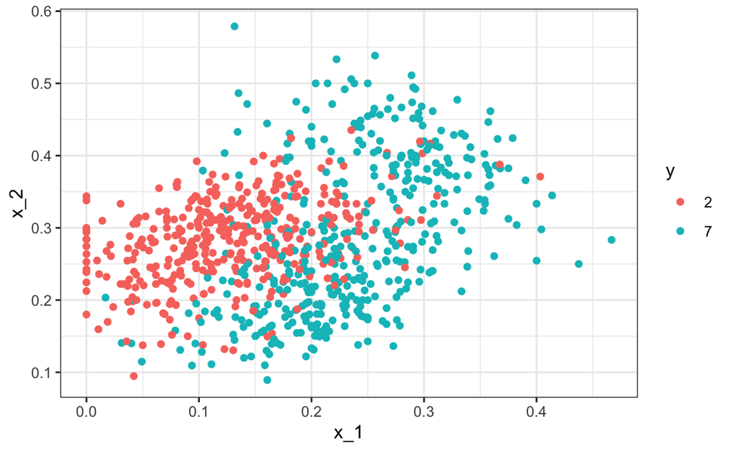

## Case study: is it a 2 or a 7?

- We can immediately see some patterns.
- For example, if \(X_1\) (the upper left panel) is very large, then the digit is probably a 7.
- Also, for smaller values of \(X_1\), the 2s appear to be in the mid range values of \(X_2\).
- To illustrate how to interpret \(X_1\) and \(X_2\), we include four example images.

## Case study: is it a 2 or a 7?

- On the left are the original images of the two digits with the largest and smallest values for \(X_1\) and on the right we have the images corresponding to the largest and smallest values of \(X_2\)

## Case study: is it a 2 or a 7?

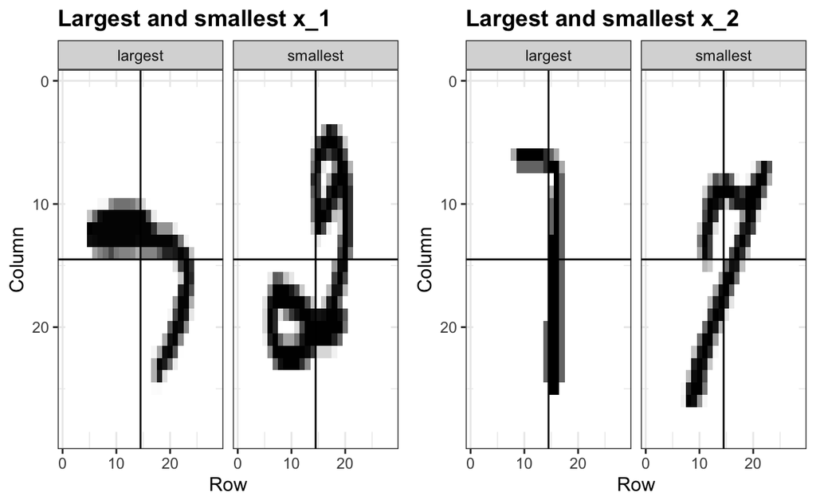

## Case study: is it a 2 or a 7?

- We can start getting a sense for why these predictors are useful, but also why the problem will be somewhat challenging.
- We haven’t really learned any algorithms yet, so let’s try building an algorithm using regression.
- The model is simply:

\[ p(x_1, x_2) = \mbox{Pr}(Y=1 \mid X_1=x_1 , X_2 = x_2) = \beta_0 + \beta_1 x_1 + \beta_2 x_2 \]

## Case study: is it a 2 or a 7?

- We fit it like this:

```r
fit <- mnist_27$train |>
  mutate(y = ifelse(y==7, 1, 0)) |>
  lm(y ~ x_1 + x_2, data = _)
```

## Case study: is it a 2 or a 7?

- We can now build a decision rule based on the estimate of \(\hat{p}(x_1, x_2)\):

```r
library(caret)
p_hat <- predict(fit, newdata = mnist_27$test)
y_hat <- factor(ifelse(p_hat > 0.5, 7, 2))
confusionMatrix(y_hat, mnist_27$test$y)$overall[["Accuracy"]]
```

```
#> [1] 0.75
```

## Case study: is it a 2 or a 7?

- We get an accuracy well above 50%.
- Not bad for our first try.
- But can we do better?
- Because we constructed the `mnist_27` example and we had at our disposal 60,000 digits in just the MNIST dataset, we used this to build the *true* conditional distribution \(p(x_1, x_2)\).

## Case study: is it a 2 or a 7?

- Keep in mind that this is something we don’t have access to in practice, but we include it in this example because it permits the comparison of \(\hat{p}(x_1, x_2)\) to the true \(p(x_1, x_2)\).
- This comparison teaches us the limitations of different algorithms.
- Let’s do that here.
- We have stored the true \(p(x_1,x_2)\) in the `mnist_27` object and can plot the image using the **ggplot2** function `geom_raster()`.

## Case study: is it a 2 or a 7?

- We choose better colors and use the `stat_contour` function to draw a curve that separates pairs \((x_1,x_2)\) for which \(p(x_1,x_2) > 0.5\) and pairs for which \(p(x_1,x_2) < 0.5\):

```r
mnist_27$true_p |> ggplot(aes(x_1, x_2, z = p, fill = p)) +
  geom_raster() +
  scale_fill_gradientn(colors=c("#F8766D", "white", "#00BFC4")) +
  stat_contour(breaks=c(0.5), color="black")
```

## Case study: is it a 2 or a 7?

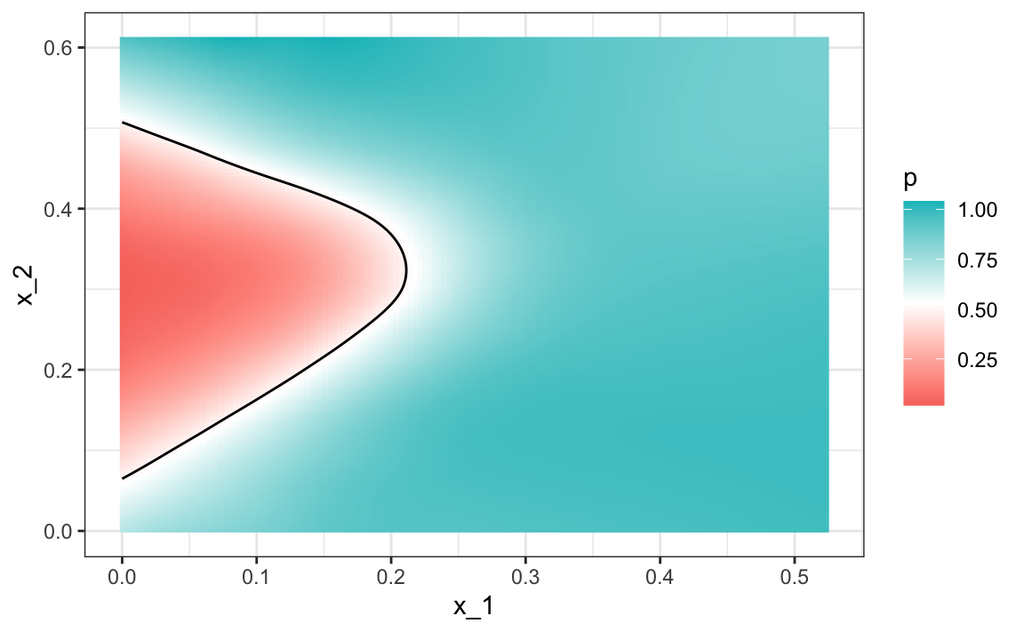

## Case study: is it a 2 or a 7?

- Above you see a plot of the true \(p(x_1, x_2)\).
- To start understanding the limitations of regression here, first note that with regression \(\hat{p}(x_1,x_2)\) has to be a plane, and as a result the boundary defined by the decision rule is given by:
- \(\hat{p}(x_1,x_2) = 0.5\), which implies the boundary can’t be anything other than a straight line:

\[ \hat{\beta}_0 + \hat{\beta}_1 x_1 + \hat{\beta}_2 x_2 = 0.5 \implies \hat{\beta}_0 + \hat{\beta}_1 x_1 + \hat{\beta}_2 x_2 = 0.5 \\ \implies x_2 = (0.5-\hat{\beta}_0)/\hat{\beta}_2 - \hat{\beta}_1/\hat{\beta}_2 x_1 \]

- Note that for this boundary, \(x_2\) is a linear function of \(x_1\).
- This implies that our regression approach has no chance of capturing the non-linear nature of the true \(p(x_1,x_2)\).

## Case study: is it a 2 or a 7?

- Below is a visual representation of \(\hat{p}(x_1, x_2)\).
- We used the `squish` function from the **scales** package to constrain estimates to be between 0 and 1.
- We can see where the mistakes were made by also showing the data and the boundary.
- They mainly come from low values \(x_1\) that have either high or low value of \(x_2\).
- Regression can’t catch this.

## Case study: is it a 2 or a 7?

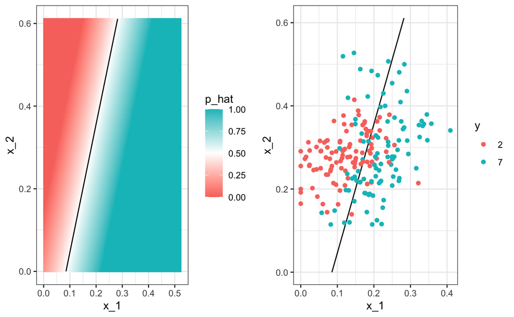

## Case study: is it a 2 or a 7?

- We need something more flexible: a method that permits estimates with shapes other than a plane.
- We are going to learn a few new algorithms based on different ideas and concepts.
- But what they all have in common is that they permit more flexible approaches.
- We will start by describing nearest neighbor and kernel approaches.

## Case study: is it a 2 or a 7?

- To introduce the concepts behinds these approaches, we will again start with a simple one-dimensional example and describe the concept of *smoothing*.